# Week 03 Assignment

19 September 2020

# 1 Matrix

Create the “rotate matrix” functions as described in lectures. Apply to “myMatrix”, called “mat” in my code.

```r
source( paste0(local.path,"WEEK-03/functions/functions-matrix.R"), local=T);

mat <- matrix(c(1, 0, 2,0, 3, 0,4, 0, 5), nrow = 3, ncol = 3,byrow = T);
rotateMatrix90(mat)
```

```
##      [,1] [,2] [,3]
## [1,]    4    0    1
## [2,]    0    3    0
## [3,]    5    0    2
```

```r
rotateMatrix180(mat)
```

```
##      [,1] [,2] [,3]
## [1,]    5    0    4
## [2,]    0    3    0
## [3,]    2    0    1
```

```r
rotateMatrix270(mat)
```

```
##      [,1] [,2] [,3]
## [1,]    2    0    5
## [2,]    0    3    0
## [3,]    1    0    4
```

# 2 IRIS

Recreate the graphic for the IRIS Data Set using R. Same titles, same scales, same colors.

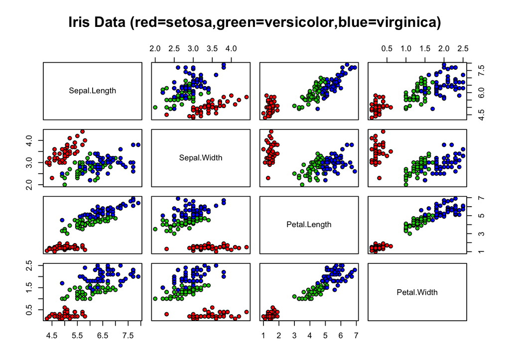

```r
data("iris")

i<- iris

pairs(~Sepal.Length+Sepal.Width+Petal.Length+Petal.Width,
      data = i,
      pch = 21,
      bg = c("red", "green3", "blue")[unclass(i$Species)],
      main = "Iris Data (red=setosa,green=versicolor,blue=virginica)",
      cex.labels=1,
      verOdd=F,
      horOdd=F)
```

3. Write 2-3 sentences concisely definiing the IRIS dataset.

The IRIS data set is comprised of width and length measurements for the petals and sepals of three Iris species that were collected by Dr. Edgar Anderson and analyzed by Sir Ronal Aylmer Fisher for the characterization of these species (Cui). This multivariate dataset is a fixture in the data science community for the exemplification of concepts in data science and machine learning due to its combined completeness, simplicity, and inherent applications for classification (Dua and Graff 2019, Wikipedia Contributors 2020).

```r
d <- read.csv("/Users/lindseykornowske/.git/STAT419/WEEK-03/functions/personality-raw.txt", header = T, sep = "|");
d <- d[,-3]
d<- d %>% separate(date_test, c("date","time"),sep = " ")
d$newdate <- strptime(as.character(d$date), "%m/%d/%Y")
d$newdate <- format(d$newdate, "%Y-%m-%d")
d<- d[,c(1,64,2:63)]
d <- d %>% separate(date, c("Month","Day","Year"), sep = "/")
#d$Year <- numeric(d$Year)
d$week <- strftime(d$newdate, format = "%V")
d <- d[,c(1:5,67,6:66)]
d<- d[with(d, order(Year, week, decreasing = T)), ]
d<- d[!duplicated(d$md5_email), ]

#write.csv(d, "personality-clean.txt", sep = "|")
```

Raw File: 838 observations Clean File: 678 observations

# 3 Summary

```r
source( paste0(local.path,"WEEK-03/functions/functions-summary.R"), local=T);
sum <- doSummary(d,8,"var2","b62c73cdaf59e0a13de495b84030734e");
sum
```

|  | V1 | V2 | V3 | V4 | V5 | V6 | V7 | V8 | V9 | V10 | V11 | V12 | V13 | V14 | V15 | V16 | V17 | V18 | V19 | V20 | V21 | V22 | V23 | V24 | V25 | V26 | V27 | V28 | V29 | … |
| --- | --- | --- | --- | --- | --- | --- | --- | --- | --- | --- | --- | --- | --- | --- | --- | --- | --- | --- | --- | --- | --- | --- | --- | --- | --- | --- | --- | --- | --- | --- |
| length | 678.00000000 | 678.0000000 | 678.0000000 | 678.0000000 | 678.0000000 | 678.0000000 | 678.0000000 | 678.0000000 | 678.0000000 | 678.0000000 | 678.000000 | 678.0000000 | 678.0000000 | 678.0000000 | 678.0000000 | 678.0000000 | 678.0000000 | 678.0000000 | 678.0000000 | 678.0000000 | 678.0000000 | 678.0000000 | 678.00000000 | 678.0000000 | 678.000000 | 678.0000000 | 678.0000000 | 678.0000000 | 678.0000000 | … |
| NA Count | 0.00000000 | 0.0000000 | 0.0000000 | 0.0000000 | 0.0000000 | 0.0000000 | 0.0000000 | 0.0000000 | 0.0000000 | 0.0000000 | 0.000000 | 0.0000000 | 0.0000000 | 0.0000000 | 0.0000000 | 0.0000000 | 0.0000000 | 0.0000000 | 0.0000000 | 0.0000000 | 0.0000000 | 0.0000000 | 0.00000000 | 0.0000000 | 0.000000 | 0.0000000 | 0.0000000 | 0.0000000 | 0.0000000 | … |
| mean | 3.42005900 | 3.5864307 | 2.4359882 | 4.0430678 | 4.1775811 | 3.8165192 | 3.8814159 | 3.1640118 | 4.3215339 | 3.8578171 | 2.997640 | 3.2831858 | 3.6725664 | 3.8306785 | 3.8991150 | 4.0890855 | 4.3038348 | 4.0749263 | 3.4849558 | 2.3415929 | 3.0247788 | 3.8436578 | 4.17286136 | 3.7917404 | 2.414749 | 4.1398230 | 3.6230088 | 3.5557522 | 2.9539823 | … |
| median | 3.40000000 | 3.4000000 | 2.6000000 | 4.2000000 | 4.2000000 | 4.2000000 | 4.2000000 | 3.4000000 | 4.2000000 | 4.2000000 | 3.400000 | 3.4000000 | 3.4000000 | 4.2000000 | 4.2000000 | 4.2000000 | 4.2000000 | 4.2000000 | 3.4000000 | 1.8000000 | 3.4000000 | 4.2000000 | 4.20000000 | 4.2000000 | 2.600000 | 4.2000000 | 3.4000000 | 3.4000000 | 2.6000000 | … |
| mode | 3.40000000 | 4.2000000 | 1.8000000 | 4.2000000 | 4.2000000 | 4.2000000 | 4.2000000 | 3.4000000 | 4.2000000 | 4.2000000 | 3.400000 | 3.4000000 | 4.2000000 | 4.2000000 | 4.2000000 | 4.2000000 | 4.2000000 | 4.2000000 | 3.4000000 | 1.8000000 | 3.4000000 | 4.2000000 | 4.20000000 | 4.2000000 | 1.800000 | 4.2000000 | 4.2000000 | 4.2000000 | 2.6000000 | … |
| sd | 1.02001187 | 1.0814641 | 1.0959317 | 0.8614014 | 0.7609168 | 0.9512605 | 0.8987648 | 0.9766566 | 0.6952738 | 0.8707062 | 1.057739 | 0.9686583 | 0.9235710 | 1.0356153 | 0.8256410 | 0.7537393 | 0.7175064 | 0.7762670 | 0.8806357 | 0.9646079 | 1.1199703 | 0.9087038 | 0.79835563 | 0.8747515 | 1.133310 | 0.8504971 | 0.8621716 | 1.0133762 | 1.0700738 | … |
| variance | 1.04042422 | 1.1695645 | 1.2010663 | 0.7420124 | 0.5789944 | 0.9048966 | 0.8077782 | 0.9538580 | 0.4834056 | 0.7581293 | 1.118813 | 0.9382988 | 0.8529834 | 1.0724991 | 0.6816831 | 0.5681229 | 0.5148154 | 0.6025905 | 0.7755193 | 0.9304684 | 1.2543334 | 0.8257426 | 0.63737171 | 0.7651902 | 1.284391 | 0.7233453 | 0.7433398 | 1.0269314 | 1.1450580 | … |
| user | 3.40000000 | 4.2000000 | 2.6000000 | 4.2000000 | 2.6000000 | 2.6000000 | 4.2000000 | 2.6000000 | 3.4000000 | 4.2000000 | 4.200000 | 3.4000000 | 3.4000000 | 4.2000000 | 5.0000000 | 3.4000000 | 5.0000000 | 3.4000000 | 1.8000000 | 2.6000000 | 2.6000000 | 2.6000000 | 4.20000000 | 3.4000000 | 5.000000 | 2.6000000 | 4.2000000 | 3.4000000 | 2.6000000 | … |
| z-score | -0.01966545 | 0.5673506 | 0.1496551 | 0.1821824 | -2.0732635 | -1.2788496 | 0.3544688 | -0.5774925 | -1.3254260 | 0.3929946 | 1.136726 | 0.1205938 | -0.2951223 | 0.3566204 | 1.3333700 | -0.9142226 | 0.9702564 | -0.8694512 | -1.9133402 | 0.2678882 | -0.3792768 | -1.3686064 | 0.03399318 | -0.4478305 | 2.281151 | -1.8104977 | 0.6692301 | -0.1536963 | -0.3308018 | … |

## 3.1 Variance

### 3.1.1 Naive

```r
doSampleVariance(d[,21], "naive")
```

```
## [1] 1.072499
```

### 3.1.2 Two Pass

```r
doSampleVariance(d[,21], "2pass")
```

```
## [1] 1.072499
```

## 3.2 Mode

```r
doMode(d[,21])
```

```
## [1] 4.2
```